# Project 2 - Australian Flight Data

George Wu (500497375)

University of Sydney | MATH1115 | October 2021

# 1 Executive Summary

The aim of this report is to provide information to Flight Centre on popular destinations and airlines. This gives airlines more information on where people are travelling and helps provide data to them so that they can focus on finding new potential areas of the world to focus on.

Our recommendations are that Flight Centre should push harder on international airlines such as Air New Zealand, Emirates, and Singapore Airlines, as well as the Australian airlines of Qantas and Jetstar. Another recommendation is that the the Chinese market gets additional attention and Chinese airline routes should be advertised more.

# 2 Initial Data Analysis (IDA)

Source data: https://data.gov.au/dataset/ds-dga-e82787e4-a480-4189-b963-1d0b6088103e/details

Data is sourced from the Australian Government’s Bureau of Infrastructure, Transport and Regional Economics.

The stakeholder/client that we are interested in communicating this data to is Flight Centre, an Australian travel agency. It is important that they understand the passenger data in order for them to understand how many people fly routes to/from Australia. This is important so that they can look at the popular destinations and the popular airlines so that they can plan special offers for routes and airlines.

Data was given to us immediately by the teaching staff for us to use. I cleaned the data by filtering for the flight data given to us in the last 6 years (2015-2021), as I felt that data before 2015 was outdated. Reasons for this include excluding data that included defunct airlines and air routes, as well as maintaining focus on recent times so that there’s a better and more refined understanding of what is going on in the travel industry.

```r
library(tidyverse)
#read the CSV file
flights = read.csv("international_airline_activity_opfltsseats_cleaned.csv")
#analyse the CSV file's feathers
dim(flights)
```

```
## [1] 39295    15
```

```r
names(flights)
```

```
##  [1] "Month"              "In_Out"             "Australian_City"
##  [4] "International_City" "Airline"            "Route"
##  [7] "Port_Country"       "Port_Region"        "Service_Country"
## [10] "Service_Region"     "Stops"              "All_Flights"
## [13] "Max_Seats"          "Year"               "Month_num"
```

```r
str(flights)
```

```
## 'data.frame':    39295 obs. of  15 variables:
##  $ Month             : chr  "Jan-15" "Jan-15" "Jan-15" "Jan-15" ...
##  $ In_Out            : chr  "I" "I" "I" "I" ...
##  $ Australian_City   : chr  "Adelaide" "Adelaide" "Adelaide" "Adelaide" ...
##  $ International_City: chr  "Auckland" "Denpasar" "Denpasar" "Dubai" ...
##  $ Airline           : chr  "Air New Zealand" "Jetstar" "Virgin Australia" "Emirates" ...
##  $ Route             : chr  "AKL-ADL" "DPS-ADL" "DPS-ADL" "DXB-ADL" ...
##  $ Port_Country      : chr  "New Zealand" "Indonesia" "Indonesia" "United Arab Emirates" ...
##  $ Port_Region       : chr  "New Zealand" "SE Asia" "SE Asia" "Middle East" ...
##  $ Service_Country   : chr  "New Zealand" "Indonesia" "Indonesia" "United Arab Emirates" ...
##  $ Service_Region    : chr  "New Zealand" "SE Asia" "SE Asia" "Middle East" ...
##  $ Stops             : int  0 0 0 0 0 0 0 0 1 0 ...
##  $ All_Flights       : int  31 31 22 31 17 15 31 45 31 5 ...
##  $ Max_Seats         : int  5043 5580 3872 10974 4267 5655 8711 12825 8122 900 ...
##  $ Year              : int  2015 2015 2015 2015 2015 2015 2015 2015 2015 2015 ...
##  $ Month_num         : int  1 1 1 1 1 1 1 1 1 1 ...
```

```r
head(flights)
```

```
##    Month In_Out Australian_City International_City                Airline
## 1 Jan-15      I        Adelaide           Auckland        Air New Zealand
## 2 Jan-15      I        Adelaide           Denpasar                Jetstar
## 3 Jan-15      I        Adelaide           Denpasar       Virgin Australia
## 4 Jan-15      I        Adelaide              Dubai               Emirates
## 5 Jan-15      I        Adelaide          Hong Kong Cathay Pacific Airways
## 6 Jan-15      I        Adelaide       Kuala Lumpur              AirAsia X
##     Route         Port_Country Port_Region      Service_Country Service_Region
## 1 AKL-ADL          New Zealand New Zealand          New Zealand    New Zealand
## 2 DPS-ADL            Indonesia     SE Asia            Indonesia        SE Asia
## 3 DPS-ADL            Indonesia     SE Asia            Indonesia        SE Asia
## 4 DXB-ADL United Arab Emirates Middle East United Arab Emirates    Middle East
## 5 HKG-ADL      Hong Kong (SAR)     NE Asia      Hong Kong (SAR)        NE Asia
## 6 KUL-ADL             Malaysia     SE Asia             Malaysia        SE Asia
##   Stops All_Flights Max_Seats Year Month_num
## 1     0          31      5043 2015         1
## 2     0          31      5580 2015         1
## 3     0          22      3872 2015         1
## 4     0          31     10974 2015         1
## 5     0          17      4267 2015         1
## 6     0          15      5655 2015         1
```

# 3 Data analysis and exploration

## 3.1 Research Question 1 (a): Which airlines are the most popular among passengers?

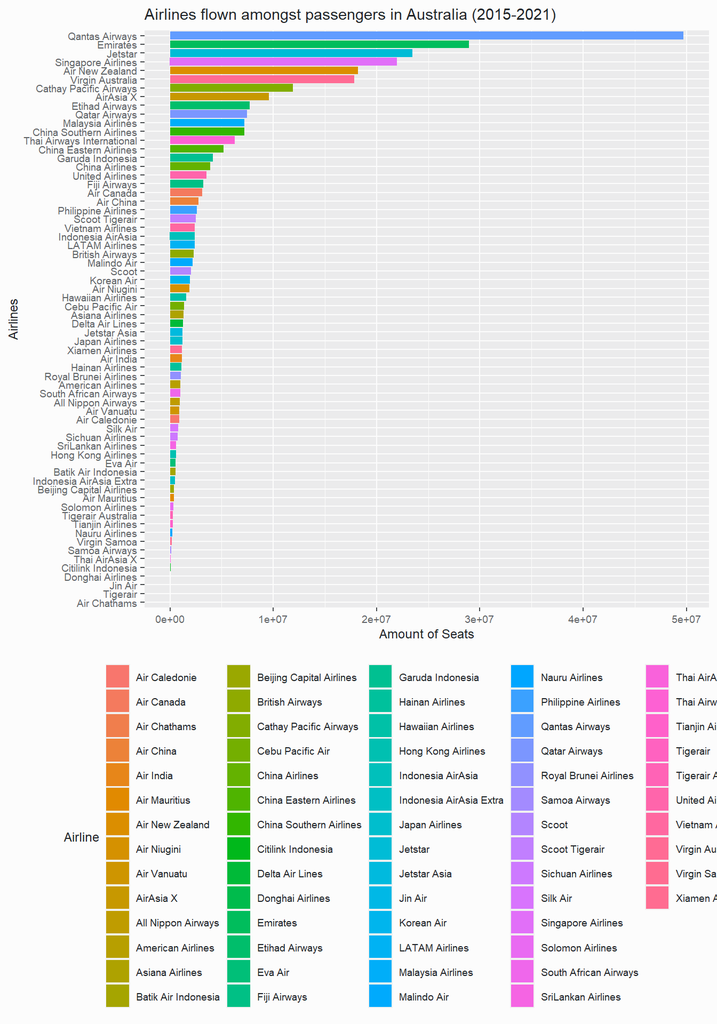

```r
library(tidyverse)
flights %>%
  #create ggplot object and create ordered bar graph
  ggplot(aes(Max_Seats, reorder(Airline, Max_Seats, sum), fill = Airline)) +
  geom_bar(stat = "identity") +
  #titles and legends
  xlab("Amount of Seats") +
  ylab("Airlines") +
  ggtitle("Airlines flown amongst passengers in Australia (2015-2021)") +
  theme(legend.position = "bottom")
```

Article: https://www.finder.com.au/which-are-the-most-popular-international-airlines-in-australia

Article explaining Virgin Australia’s administration: https://www.bbc.com/news/business-54549609#:~:text=Virgin%20Australia%20went%20into%20voluntary,to%20the%20Covid%2D19%20pandemic.

## 3.2 Research Question 1 (b): Which countries and regions are flown the most to?

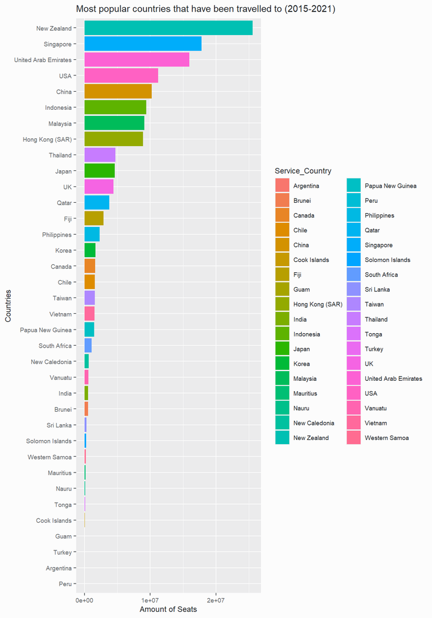

```r
library(tidyverse)
flights %>%
  #filter data for outbound flights
  filter(In_Out == "O") %>%
  #create ggplot object and create ordered bar graph
  ggplot(aes(Max_Seats, reorder(Service_Country, Max_Seats, sum), fill = Service_Country)) +
  geom_bar(stat = "identity") +
  #titles and legends
  xlab("Amount of Seats") +
  ylab("Countries") +
  ggtitle("Most popular countries that have been travelled to (2015-2021)") +
  theme(plot.title = element_text(hjust = 0))
```

Observation: New Zealand is the most popular country to travel to, followed by Singapore, UAE, USA and China.

Article: https://www.budgetdirect.com.au/travel-insurance/research/tourism-statistics.html#:~:text=New%20Zealand%20was%20the%20leading,1.4%20million%20trips%20in%202019.

Insurance company Budget Direct ran an article which looks at Australian tourism statistics, in which their top 5 list comprised of New Zealand, Indonesia, USA, UK and China. It is interesting to note that Singapore was not a top destination in Budget Direct’s article, whilst Singapore came second and Indonesia came sixth.

## 3.3 Research Question 1 (c): Is there a relationship between the Total Amount of Flights and Max Seats?

As there are too many airlines to consider when looking at the data, we will consider only the top 4 airlines. The top 4 airlines can be seen in the graph from Research Question 1 (a).

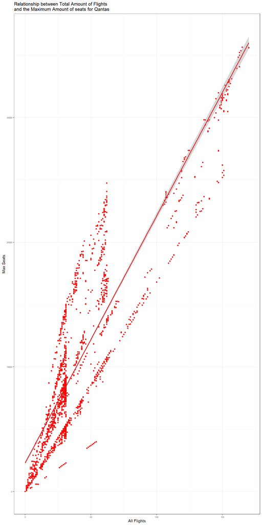

```r
library(tidyverse)
qantas <-
  flights %>%
  #filter for specific airlines
    filter(Airline == "Qantas Airways") %>%
    ggplot(aes(All_Flights, Max_Seats)) +
  #choose colour that correlates best to airline livery
    geom_point(colour = "#FC0000") +
    geom_smooth(method = "lm", colour = "#FC0000") +
  #titles and legends
    theme_bw() +
    xlab("All Flights") +
    ylab("Max Seats") +
    ggtitle("Relationship between Total Amount of Flights\nand the Maximum Amount of seats for Qantas")

emirates <-
  flights %>%
    filter(Airline == "Emirates") %>%
    ggplot(aes(All_Flights, Max_Seats, colour = Airline)) +
    geom_point(colour = "#006400") +
    geom_smooth(method = "lm", colour = "#006400") +
    theme_bw() +
    xlab("All Flights") +
    ylab("Max Seats") +
    ggtitle("Relationship between Total Amount of Flights\nand the Maximum Amount of seats for Emirates")

jetstar <-
  flights %>%
    filter(Airline == "Jetstar") %>%
    ggplot(aes(All_Flights, Max_Seats, colour = Airline)) +
    geom_point(colour = "#FFA500") +
    geom_smooth(method = "lm", colour = "#FFA500") +
    theme_bw() +
    xlab("All Flights") +
    ylab("Max Seats") +
    ggtitle("Relationship between Total Amount of Flights\nand the Maximum Amount of seats for Jetstar")

singapore_airlines <-
  flights %>%
    filter(Airline == "Singapore Airlines") %>%
    ggplot(aes(All_Flights, Max_Seats, colour = Airline)) +
    geom_point(colour = "#00008b") +
    geom_smooth(method = "lm", colour = "#00008b") +
    theme_bw() +
    xlab("All Flights") +
    ylab("Max Seats") +
    ggtitle("Relationship between Total Amount of Flights\nand the Maximum Amount of seats for Singapore Airlines")

qantas
```

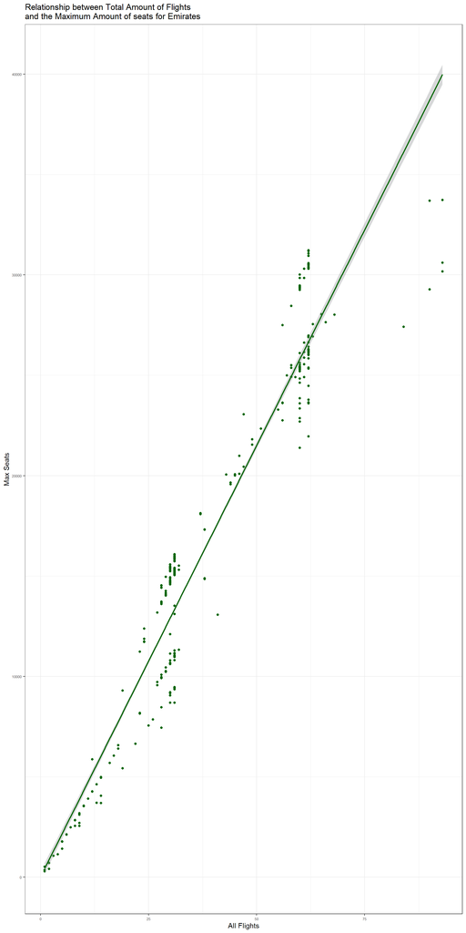

```r
emirates
```

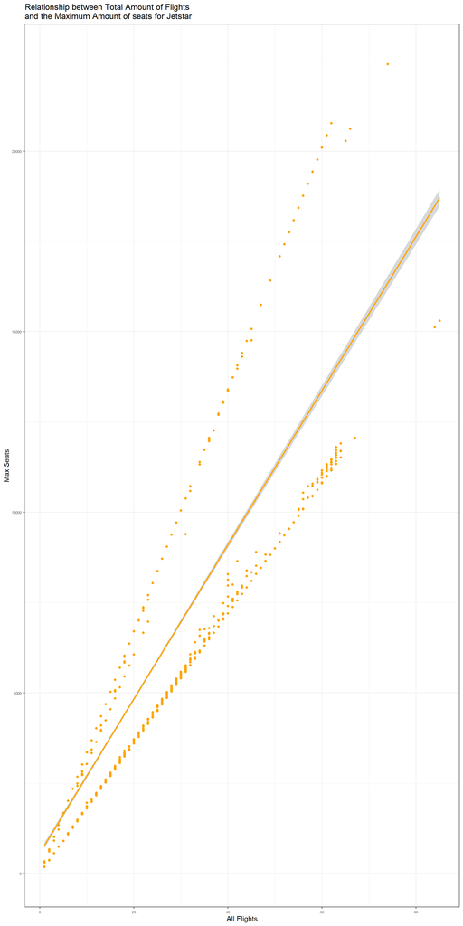

```r
jetstar
```

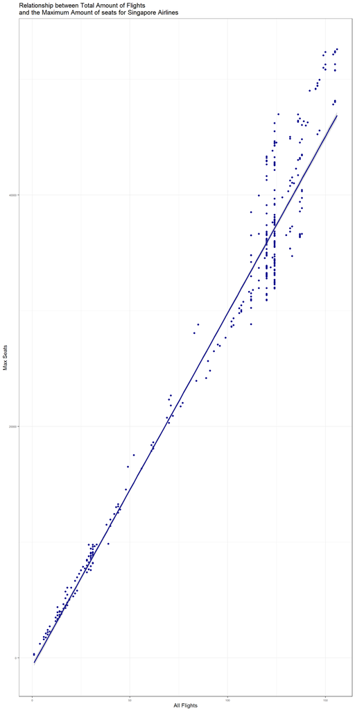

```r
singapore_airlines
```

Given that China also appeared as a top destination that is flown by passengers entering/leaving Australia, it is important that the Chinese airlines’ relationship with their total flights and amount of seats be analysed as well.

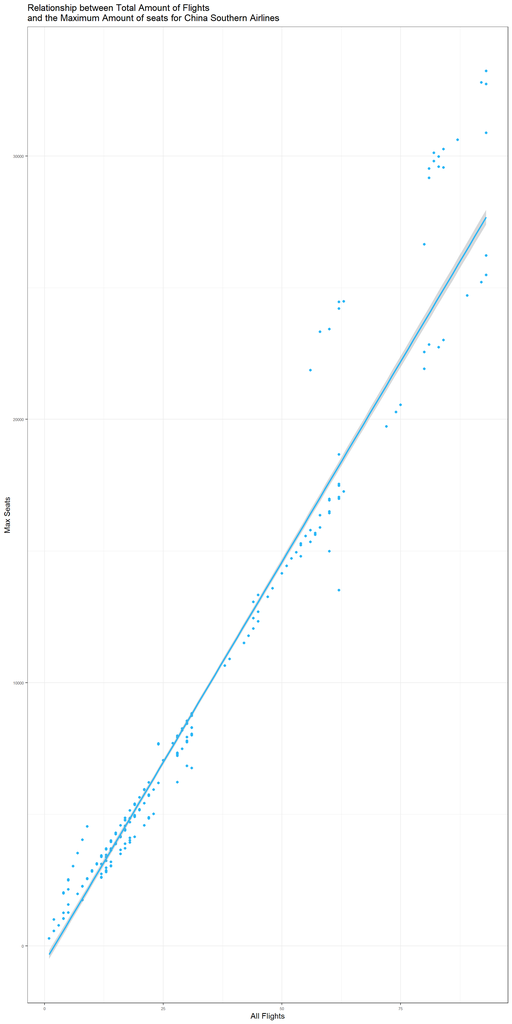

```r
library(tidyverse)

china_southern <-
  flights %>%
    filter(Airline == "China Southern Airlines") %>%
    ggplot(aes(All_Flights, Max_Seats)) +
    geom_point(colour = "#29b6f6") +
    geom_smooth(method = "lm", colour = "#29b6f6") +
    theme_bw() +
    xlab("All Flights") +
    ylab("Max Seats") +
    ggtitle("Relationship between Total Amount of Flights\nand the Maximum Amount of seats for China Southern Airlines")

china_eastern <-
  flights %>%
    filter(Airline == "China Eastern Airlines") %>%
    ggplot(aes(All_Flights, Max_Seats, colour = Airline)) +
    geom_point(colour = "#8b0000") +
    geom_smooth(method = "lm", colour = "#8b0000") +
    theme_bw() +
    xlab("All Flights") +
    ylab("Max Seats") +
    ggtitle("Relationship between Total Amount of Flights\nand the Maximum Amount of seats for China Eastern Airlines")

air_china <-
  flights %>%
    filter(Airline == "Air China") %>%
    ggplot(aes(All_Flights, Max_Seats, colour = Airline)) +
    geom_point(colour = "#000000") +
    geom_smooth(method = "lm", colour = "#000000") +
    theme_bw() +
    xlab("All Flights") +
    ylab("Max Seats") +
    ggtitle("Relationship between Total Amount of Flights\nand the Maximum Amount of seats for Air China")

china_southern
```

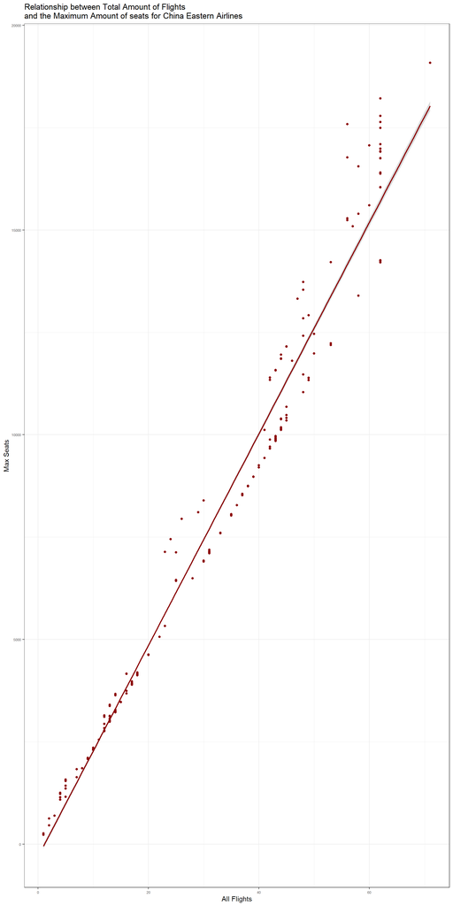

```r
china_eastern
```

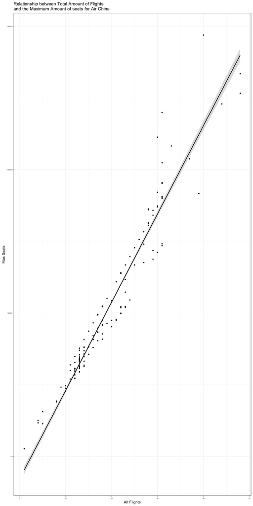

```r
air_china
```

```r
# Regression test
qantas_data <-
  flights %>%
  filter(Airline == "Qantas Airways")

lm(All_Flights ~ Max_Seats, data = qantas_data)
```

```
##
## Call:
## lm(formula = All_Flights ~ Max_Seats, data = qantas_data)
##
## Coefficients:
## (Intercept)    Max_Seats
##    2.430035     0.003387
```

```r
summary(lm(All_Flights ~ Max_Seats, data = qantas_data))
```

```
##
## Call:
## lm(formula = All_Flights ~ Max_Seats, data = qantas_data)
##
## Residuals:
##     Min      1Q  Median      3Q     Max
## -25.487  -7.674  -1.718   4.552  62.655
##
## Coefficients:
##              Estimate Std. Error t value Pr(>|t|)
## (Intercept) 2.430e+00  3.175e-01   7.654 2.27e-14 ***
## Max_Seats   3.387e-03  3.092e-05 109.545  < 2e-16 ***
## ---
## Signif. codes:  0 '***' 0.001 '**' 0.01 '*' 0.05 '.' 0.1 ' ' 1
##
## Residual standard error: 13.76 on 5867 degrees of freedom
## Multiple R-squared:  0.6716, Adjusted R-squared:  0.6716
## F-statistic: 1.2e+04 on 1 and 5867 DF,  p-value: < 2.2e-16
```

```r
emirates_data <-
  flights %>%
  filter(Airline == "Emirates")
lm(All_Flights ~ Max_Seats, data = emirates_data)
```

```
##
## Call:
## lm(formula = All_Flights ~ Max_Seats, data = emirates_data)
##
## Coefficients:
## (Intercept)    Max_Seats
##    4.942630     0.001971
```

```r
summary(lm(All_Flights ~ Max_Seats, data = emirates_data))
```

```
##
## Call:
## lm(formula = All_Flights ~ Max_Seats, data = emirates_data)
##
## Residuals:
##    Min     1Q Median     3Q    Max
## -5.655 -3.857 -2.525  4.125 28.599
##
## Coefficients:
##              Estimate Std. Error t value Pr(>|t|)
## (Intercept) 4.943e+00  2.789e-01   17.72   <2e-16 ***
## Max_Seats   1.971e-03  1.845e-05  106.83   <2e-16 ***
## ---
## Signif. codes:  0 '***' 0.001 '**' 0.01 '*' 0.05 '.' 0.1 ' ' 1
##
## Residual standard error: 4.757 on 2063 degrees of freedom
## Multiple R-squared:  0.8469, Adjusted R-squared:  0.8468
## F-statistic: 1.141e+04 on 1 and 2063 DF,  p-value: < 2.2e-16
```

```r
jetstar_data <-
  flights %>%
  filter(Airline == "Jetstar")
lm(All_Flights ~ Max_Seats, data = jetstar_data)
```

```
##
## Call:
## lm(formula = All_Flights ~ Max_Seats, data = jetstar_data)
##
## Coefficients:
## (Intercept)    Max_Seats
##    2.937686     0.003469
```

```r
summary(lm(All_Flights ~ Max_Seats, data = jetstar_data))
```

```
##
## Call:
## lm(formula = All_Flights ~ Max_Seats, data = jetstar_data)
##
## Residuals:
##     Min      1Q  Median      3Q     Max
## -12.986  -5.045  -3.262   4.868  28.988
##
## Coefficients:
##              Estimate Std. Error t value Pr(>|t|)
## (Intercept) 2.938e+00  1.612e-01   18.23   <2e-16 ***
## Max_Seats   3.469e-03  2.879e-05  120.51   <2e-16 ***
## ---
## Signif. codes:  0 '***' 0.001 '**' 0.01 '*' 0.05 '.' 0.1 ' ' 1
##
## Residual standard error: 6.531 on 5094 degrees of freedom
## Multiple R-squared:  0.7403, Adjusted R-squared:  0.7403
## F-statistic: 1.452e+04 on 1 and 5094 DF,  p-value: < 2.2e-16
```

```r
singapore_data <-
  flights %>%
  filter(Airline == "Singapore Airlines")
lm(All_Flights ~ Max_Seats, data = singapore_data)
```

```
##
## Call:
## lm(formula = All_Flights ~ Max_Seats, data = singapore_data)
##
## Coefficients:
## (Intercept)    Max_Seats
##    4.134883     0.003191
```

```r
summary(lm(All_Flights ~ Max_Seats, data = singapore_data))
```

```
##
## Call:
## lm(formula = All_Flights ~ Max_Seats, data = singapore_data)
##
## Residuals:
##     Min      1Q  Median      3Q     Max
## -28.039  -2.594  -1.327   4.468  18.057
##
## Coefficients:
##              Estimate Std. Error t value Pr(>|t|)
## (Intercept) 4.135e+00  4.209e-01   9.823   <2e-16 ***
## Max_Seats   3.191e-03  1.617e-05 197.307   <2e-16 ***
## ---
## Signif. codes:  0 '***' 0.001 '**' 0.01 '*' 0.05 '.' 0.1 ' ' 1
##
## Residual standard error: 8.11 on 1048 degrees of freedom
## Multiple R-squared:  0.9738, Adjusted R-squared:  0.9738
## F-statistic: 3.893e+04 on 1 and 1048 DF,  p-value: < 2.2e-16
```

```r
china_southern_data <-
  flights %>%
  filter(Airline == "China Southern Airlines")
lm(All_Flights ~ Max_Seats, data = china_southern_data)
```

```
##
## Call:
## lm(formula = All_Flights ~ Max_Seats, data = china_southern_data)
##
## Coefficients:
## (Intercept)    Max_Seats
##    3.207989     0.003155
```

```r
summary(lm(All_Flights ~ Max_Seats, data = china_southern_data))
```

```
##
## Call:
## lm(formula = All_Flights ~ Max_Seats, data = china_southern_data)
##
## Residuals:
##      Min       1Q   Median       3Q      Max
## -18.8060  -1.8565  -0.0782   2.5579  16.1482
##
## Coefficients:
##              Estimate Std. Error t value Pr(>|t|)
## (Intercept) 3.208e+00  2.562e-01   12.52   <2e-16 ***
## Max_Seats   3.155e-03  2.236e-05  141.10   <2e-16 ***
## ---
## Signif. codes:  0 '***' 0.001 '**' 0.01 '*' 0.05 '.' 0.1 ' ' 1
##
## Residual standard error: 4.683 on 814 degrees of freedom
## Multiple R-squared:  0.9607, Adjusted R-squared:  0.9607
## F-statistic: 1.991e+04 on 1 and 814 DF,  p-value: < 2.2e-16
```

```r
china_eastern_data <-
  flights %>%
  filter(Airline == "China Eastern Airlines")
lm(All_Flights ~ Max_Seats, data = china_eastern_data)
```

```
##
## Call:
## lm(formula = All_Flights ~ Max_Seats, data = china_eastern_data)
##
## Coefficients:
## (Intercept)    Max_Seats
##    1.533604     0.003801
```

```r
summary(lm(All_Flights ~ Max_Seats, data = china_eastern_data))
```

```
##
## Call:
## lm(formula = All_Flights ~ Max_Seats, data = china_eastern_data)
##
## Residuals:
##      Min       1Q   Median       3Q      Max
## -12.3670  -0.5697   0.1020   0.2278   6.4645
##
## Coefficients:
##              Estimate Std. Error t value Pr(>|t|)
## (Intercept) 1.534e+00  1.046e-01   14.66   <2e-16 ***
## Max_Seats   3.801e-03  1.631e-05  233.07   <2e-16 ***
## ---
## Signif. codes:  0 '***' 0.001 '**' 0.01 '*' 0.05 '.' 0.1 ' ' 1
##
## Residual standard error: 2.092 on 1028 degrees of freedom
## Multiple R-squared:  0.9814, Adjusted R-squared:  0.9814
## F-statistic: 5.432e+04 on 1 and 1028 DF,  p-value: < 2.2e-16
```

```r
air_china_data <-
  flights %>%
  filter(Airline == "Air China")
lm(All_Flights ~ Max_Seats, data = air_china_data)
```

```
##
## Call:
## lm(formula = All_Flights ~ Max_Seats, data = air_china_data)
##
## Coefficients:
## (Intercept)    Max_Seats
##    3.717740     0.003002
```

```r
summary(lm(All_Flights ~ Max_Seats, data = air_china_data))
```

```
##
## Call:
## lm(formula = All_Flights ~ Max_Seats, data = air_china_data)
##
## Residuals:
##     Min      1Q  Median      3Q     Max
## -8.7372 -0.9500  0.0319  0.6088  7.7565
##
## Coefficients:
##              Estimate Std. Error t value Pr(>|t|)
## (Intercept) 3.718e+00  1.956e-01   19.01   <2e-16 ***
## Max_Seats   3.002e-03  3.615e-05   83.05   <2e-16 ***
## ---
## Signif. codes:  0 '***' 0.001 '**' 0.01 '*' 0.05 '.' 0.1 ' ' 1
##
## Residual standard error: 2.058 on 562 degrees of freedom
## Multiple R-squared:  0.9247, Adjusted R-squared:  0.9245
## F-statistic:  6897 on 1 and 562 DF,  p-value: < 2.2e-16
```

From what we are able to see with the linear regression tests, we see that the R<sup>2</sup> values range from 0.67 to 0.98, and all the p-values are less than 0.01, which represent an overall significant linear relationship.

```r
library(MASS)
```

**Hypotheses:**

- $H_0$: A relationship between the total amount of flights and max seats does not exist.
- $H_1$: A relationship between the total amount of flights and max seats exists.

```r
t.test(flights$All_Flights, flights$Max_Seats, var.equal = TRUE)
```

```
##
##  Two Sample t-test
##
## data:  flights$All_Flights and flights$Max_Seats
## t = -216.59, df = 78588, p-value < 2.2e-16
## alternative hypothesis: true difference in means is not equal to 0
## 95 percent confidence interval:
##  -7403.820 -7271.023
## sample estimates:
##  mean of x  mean of y
##   27.32192 7364.74328
```

# 4 References

Kidman, A. (2016, June 1) Which are the most popular international airlines in Australia?. Finder. https://www.finder.com.au/which-are-the-most-popular-international-airlines-in-australia

Australian Tourism Statistics 2020. Budget Direct. https://www.budgetdirect.com.au/travel-insurance/research/tourism-statistics.html#:~:text=New%20Zealand%20was%20the%20leading,1.4%20million%20trips%20in%202019.